# League of Legends Ranked Data

## Overview

League of Legends is a 5v5 game where two teams directly compete to destroy the nexus, or giant crystal located in the enemy team's base, first. To help them accomplish this, smaller goals are located around the map, known as objectives. Objectives come in two forms: structures, and neutral monsters. Structures include towers and inhibitors and they defend each team's nexus. To win the game, each team must destroy the enemy team's structures before the nexus as per the game's rules. Neutral monsters spawn near the center of the map and are claimed by either team by defeating the monster. While claiming neutral monster objectives are not directly necessary to win the game, the buffs they provide the team that claims them can help them more easily destroy structures and win the game. Because there are different objectives, many people debate which objectives are the most important to claim to give them the highest chance of winning the game.

The purpose of this project is to find trends in the data of League of Legends ranked games on the eu-west server to find which objectives are most useful for winning games. Rather than focusing on champion picks, we will focus on how objectives influence the game. This is because while champions change power levels frequently, objectives usually stay relatively equal strength and are consistent in every game. In this tutorial, we will visualize and measure correlations between various objectives and winning games and find out if early objectives can be used to predict a game result.

## Required Tools

This tutorial was created in Jupyter Notebooks with the following libraries: pands, numpy, matplotlib, math, scipy, sklearn

The dataset I used can be found here: https://www.kaggle.com/datasets/datasnaek/league-of-legends

## Importing Required Libraries

```python
# Import libraries
import pandas as pd
import numpy as np
import matplotlib.pyplot as plt
import math
import scipy.stats
from sklearn.tree import DecisionTreeClassifier
from sklearn.model_selection import train_test_split
from sklearn.model_selection import StratifiedKFold
from sklearn import tree
```

# Data Collection and Curation

The first step in the data science pipeline is data collection and curation. In this step, we collect the data and adjust it to be in a viewable format.

## Importing Data

From the link above, we download the file games.csv and use pandas to read the file as a dataframe.

More information on dataframes can be found here: https://pandas.pydata.org/docs/reference/api/pandas.DataFrame.html

```python
# Read data file
data = pd.read_csv("games.csv", dtype=object)

data.head()
```

|  | gameId | creationTime | gameDuration | seasonId | winner | firstBlood | firstTower | firstInhibitor | firstBaron | firstDragon | ... | t2_towerKills | t2_inhibitorKills | t2_baronKills | t2_dragonKills | t2_riftHeraldKills | t2_ban1 | t2_ban2 | t2_ban3 | t2_ban4 | t2_ban5 |
| --- | --- | --- | --- | --- | --- | --- | --- | --- | --- | --- | --- | --- | --- | --- | --- | --- | --- | --- | --- | --- | --- |
| 0 | 3326086514 | 1504279457970 | 1949 | 9 | 1 | 2 | 1 | 1 | 1 | 1 | ... | 5 | 0 | 0 | 1 | 1 | 114 | 67 | 43 | 16 | 51 |
| 1 | 3229566029 | 1497848803862 | 1851 | 9 | 1 | 1 | 1 | 1 | 0 | 1 | ... | 2 | 0 | 0 | 0 | 0 | 11 | 67 | 238 | 51 | 420 |
| 2 | 3327363504 | 1504360103310 | 1493 | 9 | 1 | 2 | 1 | 1 | 1 | 2 | ... | 2 | 0 | 0 | 1 | 0 | 157 | 238 | 121 | 57 | 28 |
| 3 | 3326856598 | 1504348503996 | 1758 | 9 | 1 | 1 | 1 | 1 | 1 | 1 | ... | 0 | 0 | 0 | 0 | 0 | 164 | 18 | 141 | 40 | 51 |
| 4 | 3330080762 | 1504554410899 | 2094 | 9 | 1 | 2 | 1 | 1 | 1 | 1 | ... | 3 | 0 | 0 | 1 | 0 | 86 | 11 | 201 | 122 | 18 |

5 rows × 61 columns

# Data management/representation

The next step in the pipeline is to transform the data so we can more easily analyze it in later steps

To clean the data, we can drop fields like gameId, creationTime, and seasonID since those do not differentiate the games and are not important factors for deciding who wins a game. We can also drop information on the champions on each team and the summoners they took. This is because we want to find common trends in the games themselves that are not dependent on champions since champion strengths can change over time.

```python
# Drop columns unnecessary to our analysis
data = data.drop(['gameId', 'creationTime', 'seasonId'], axis=1)
data = data.drop(['t1_champ1id', 't1_champ1_sum1', 't1_champ1_sum2', 't1_champ2id', 't1_champ2_sum1', 't1_champ2_sum2',
           't1_champ3id', 't1_champ3_sum1', 't1_champ3_sum2', 't1_champ4id', 't1_champ4_sum1', 't1_champ4_sum2',
           't1_champ5id', 't1_champ5_sum1', 't1_champ5_sum2', 't2_champ1id', 't2_champ1_sum1', 't2_champ1_sum2',
           't2_champ2id', 't2_champ2_sum1', 't2_champ2_sum2', 't2_champ3id', 't2_champ3_sum1', 't2_champ3_sum2',
           't2_champ4id', 't2_champ4_sum1', 't2_champ4_sum2', 't2_champ5id', 't2_champ5_sum1', 't2_champ5_sum2',
           't1_ban1', 't1_ban2', 't1_ban3', 't1_ban4', 't1_ban5', 't2_ban1', 't2_ban2', 't2_ban3', 't2_ban4', 't2_ban5'], axis=1)
data.head()
```

|  | gameDuration | winner | firstBlood | firstTower | firstInhibitor | firstBaron | firstDragon | firstRiftHerald | t1_towerKills | t1_inhibitorKills | t1_baronKills | t1_dragonKills | t1_riftHeraldKills | t2_towerKills | t2_inhibitorKills | t2_baronKills | t2_dragonKills | t2_riftHeraldKills |
| --- | --- | --- | --- | --- | --- | --- | --- | --- | --- | --- | --- | --- | --- | --- | --- | --- | --- | --- |
| 0 | 1949 | 1 | 2 | 1 | 1 | 1 | 1 | 2 | 11 | 1 | 2 | 3 | 0 | 5 | 0 | 0 | 1 | 1 |
| 1 | 1851 | 1 | 1 | 1 | 1 | 0 | 1 | 1 | 10 | 4 | 0 | 2 | 1 | 2 | 0 | 0 | 0 | 0 |
| 2 | 1493 | 1 | 2 | 1 | 1 | 1 | 2 | 0 | 8 | 1 | 1 | 1 | 0 | 2 | 0 | 0 | 1 | 0 |
| 3 | 1758 | 1 | 1 | 1 | 1 | 1 | 1 | 0 | 9 | 2 | 1 | 2 | 0 | 0 | 0 | 0 | 0 | 0 |
| 4 | 2094 | 1 | 2 | 1 | 1 | 1 | 1 | 0 | 9 | 2 | 1 | 3 | 0 | 3 | 0 | 0 | 1 | 0 |

The objectives we want to consider are which team gets the first herald, first dragon, first baron, first blood or first kill, first tower, and first inhibitor. Out of these objectives, herald, dragon, and baron are neutral monster objectives and do not need to be taken to end the game, so I included a counter for how many games did not have either team taking any of those objectives. Although kills technically are not necessary to win the game, it is unheard of for a game to end with no deaths. While an inhibitor is a necessary objective to end the game, they are usually taken later in the game and it is possible for one team to forfeit the game before one is taken, so a counter for games without an inhibitor is kept. The first tower is taken relatively early in the game and is a vital objective so it is also unheard of for a game to end without one being taken. This is why first blood and first tower do not have a counter for games without them.

```python
# Initialize counters for each objective
no_herald = 0
first_herald_win = 0
first_herald_lose = 0

no_dragon = 0
first_dragon_win = 0
first_dragon_lose = 0

first_blood_win = 0
first_blood_lose = 0

first_tower_win = 0
first_tower_lose = 0

no_baron = 0
first_baron_win = 0
first_baron_lose = 0

no_inhib = 0
first_inhib_win = 0
first_inhib_lose = 0

# Loop through rows and count how many of each scenario happened
for index, game in data.iterrows():
    if game['firstRiftHerald'] == '0':
        no_herald = no_herald + 1
    elif game['firstRiftHerald'] == '1' and game['winner'] == '1':
        first_herald_win = first_herald_win + 1
    elif game['firstRiftHerald'] == '2' and game['winner'] == '2':
        first_herald_win = first_herald_win + 1
    else:
        first_herald_lose = first_herald_lose + 1
    if game['firstDragon'] == '0':
        no_dragon = no_dragon + 1
    elif game['firstDragon'] == '1' and game['winner'] == '1':
        first_dragon_win = first_dragon_win + 1
    elif game['firstDragon'] == '2' and game['winner'] == '2':
        first_dragon_win = first_dragon_win + 1
    else:
        first_dragon_lose = first_dragon_lose + 1
    if game['firstBlood'] == '1' and game['winner'] == '1':
        first_blood_win = first_blood_win + 1
    elif game['firstBlood'] == '2' and game['winner'] == '2':
        first_blood_win = first_blood_win + 1
    else:
        first_blood_lose = first_blood_lose + 1
    if game['firstTower'] == '1' and game['winner'] == '1':
        first_tower_win = first_tower_win + 1
    elif game['firstTower'] == '2' and game['winner'] == '2':
        first_tower_win = first_tower_win + 1
    else:
        first_tower_lose = first_tower_lose + 1
    if game['firstInhibitor'] == '0':
        no_inhib = no_inhib + 1
    elif game['firstInhibitor'] == '1' and game['winner'] == '1':
        first_inhib_win = first_inhib_win + 1
    elif game['firstInhibitor'] == '2' and game['winner'] == '2':
        first_inhib_win = first_inhib_win + 1
    else:
        first_inhib_lose = first_inhib_lose + 1
    if game['firstBaron'] == '0':
        no_baron = no_baron + 1
    elif game['firstBaron'] == '1' and game['winner'] == '1':
        first_baron_win = first_baron_win + 1
    elif game['firstBaron'] == '2' and game['winner'] == '2':
        first_baron_win = first_baron_win + 1
    else:
        first_baron_lose = first_baron_lose + 1
```

# Exploratory Data Analysis

The third step in the pipeline is to start playing around with factors of the data we are interested in. Once we see any interesting trends, we can do further analysis to explore those trends more in-depth.

First, we want to show the effects of first rift herald, first dragon, first blood, and first tower. I grouped these objectives together because they are achieved relatively early in the game. Because these objectives are usually taken in a neutral game state and give one team an advantage, showing how often taking the first objective results in a win is an indicator of how large the advantage is.

More information on making bar graph- https://www.geeksforgeeks.org/bar-plot-in-matplotlib/

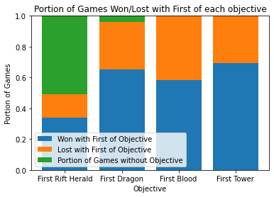

```python
# Create labels and data to plot
labels = ['First Rift Herald', 'First Dragon', 'First Blood', 'First Tower']
win_percentage = [first_herald_win/data.shape[0], first_dragon_win/data.shape[0], first_blood_win/data.shape[0], first_tower_win/data.shape[0]]
lose_percentage = [first_herald_lose/data.shape[0], first_dragon_lose/data.shape[0], first_blood_lose/data.shape[0], first_tower_lose/data.shape[0]]
not_present_percentage = [no_herald/data.shape[0], no_dragon/data.shape[0], 0, 0]

# Plot Data
fig, ax = plt.subplots()
ax.bar(labels, win_percentage, label='Won with First of Objective')
ax.bar(labels, lose_percentage, bottom=win_percentage, label='Lost with First of Objective')
ax.bar(labels, not_present_percentage, bottom=np.add(win_percentage,lose_percentage), label='Portion of Games without Objective')
ax.set_xlabel('Objective')
ax.set_ylabel('Portion of Games')
ax.set_title('Portion of Games Won/Lost with First of each objective')
ax.legend()

plt.show()
```

The graph shows that in the games where the objective was taken, the team was usually given an advantage that helped win the game. I was surprised to see that in about half of the games, rift herald was not taken at all. This shows that most teams do not value herald highly enough to take it, even though in the portion it was taken the team that took it often won the game. First blood appears to be the objective that has the lowest influence in determining who wins the game. This could be because it often happens the earliest where the game is the most even and the advantage it gives is recoverable. The first dragon and tower usually are taken later in the game, so which team takes it can be influenced by which team is winning at the time.

The next objectives we will consider are the first baron and inhibitor taken. Because these are later game objectives, they are heavily influenced by the game state and which team is winning. Because they can be an indicator of the winning team, we expect the portion of teams that took the objective to be much higher than the objectives we looked at previously.

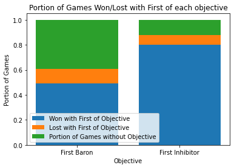

```python
# Create labels and data to plot
labels = ['First Baron', 'First Inhibitor']
win_percentage = [first_baron_win/data.shape[0], first_inhib_win/data.shape[0]]
lose_percentage = [first_baron_lose/data.shape[0], first_inhib_lose/data.shape[0]]
not_present_percentage = [no_baron/data.shape[0], no_inhib/data.shape[0]]

# Plot Data
fig, ax = plt.subplots()
ax.bar(labels, win_percentage, label='Won with First of Objective')
ax.bar(labels, lose_percentage, bottom=win_percentage, label='Lost with First of Objective')
ax.bar(labels, not_present_percentage, bottom=np.add(win_percentage,lose_percentage), label='Portion of Games without Objective')
ax.set_xlabel('Objective')
ax.set_ylabel('Portion of Games')
ax.set_title('Portion of Games Won/Lost with First of each objective')
ax.legend()

plt.show()
```

We can see that in the games in which the team took the first of either objective, they often won the game. The games in which no inhibitor was taken can only be due to one team forfeiting since it is not possible to win normally without taking an inhibitor according to the game's rules. Since in the games where baron was taken the team often won, it is surprising that in almost 40% of games baron was not taken by either team. This could be attributed to games ending too quickly, as baron spawns at 20 minutes so games that lasted a shorter amount would not give either team a chance to take the baron. To account for this we will filter the dataframe to only include games that were longer than 20 minutes.

```
Games longer than 20 minutes: 47848
```

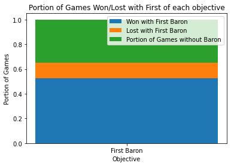

```python
# Initialize counters
no_baron = 0
first_baron_win = 0
first_baron_lose = 0

# Count each scenario for game times over 20 minutes (1200 seconds)
for index, game in data[data["gameDuration"].astype(int) > 1200].iterrows():
    if game['firstBaron'] == '0':
        no_baron = no_baron + 1
    elif game['firstBaron'] == '1' and game['winner'] == '1':
        first_baron_win = first_baron_win + 1
    elif game['firstBaron'] == '2' and game['winner'] == '2':
        first_baron_win = first_baron_win + 1
    else:
        first_baron_lose = first_baron_lose + 1

# Create labels and data to plot
first_baron_wr = first_baron_win/data[data["gameDuration"].astype(int) > 1200].shape[0]
first_baron_lr = first_baron_lose/data[data["gameDuration"].astype(int) > 1200].shape[0]
not_present_rate = no_baron/data[data["gameDuration"].astype(int) > 1200].shape[0]
print(f"Games longer than 20 minutes: { data[data['gameDuration'].astype(int) > 1200].shape[0] }")

# Plot Data
fig, ax = plt.subplots()
ax.bar(['First Baron'], first_baron_wr, label='Won with First Baron')
ax.bar(['First Baron'], first_baron_lr, bottom=first_baron_wr, label='Lost with First Baron')
ax.bar(['First Baron'], not_present_rate, bottom=first_baron_wr+first_baron_lr, label='Portion of Games without Baron')
ax.set_xlabel('Objective')
ax.set_ylabel('Portion of Games')
ax.set_title('Portion of Games Won/Lost with First of each objective')
ax.legend()

plt.show()
```

# Hypothesis Testing

The fourth step in the pipeline is to test hypotheses. After noting any interesting trends in the previous step, we can more deeply analyze and test whether these trends are significant or the product of chance.

In the previous graph, we saw that the first tower is the early game objective that had highest conversion into winning the game. We also saw that herald had a low priority compared to the other neutral objective, dragon. Since the herald is intended to be used to crash into towers to help take them, I wanted to find if the herald actually converts into taking the first tower more often or if the time spent taking the herald can be better used to secure first tower another way. Because the team that takes the first tower and first herald are binary, I used the point-biserial version of the Pearson coefficient to find the degree of relationship between the two variables. I also took out the games where the herald was not taken to so we could observe the effect the herald had on the games.

More information on point-biseral correlation - https://en.wikipedia.org/wiki/Point-biserial_correlation_coefficient

More information on different types of correlation - https://www.statisticssolutions.com/free-resources/directory-of-statistical-analyses/correlation-pearson-kendall-spearman/

```python
# Filter data to first tower and herald and check correlation
check_corr = data.filter(['firstTower', 'firstRiftHerald'])
check_corr = check_corr.loc[check_corr['firstRiftHerald'] != '0']
check_corr = check_corr.astype(int)-1
check_corr.corr()
```

|  | firstTower | firstRiftHerald |
| --- | --- | --- |
| firstTower | 1.000000 | 0.441577 |
| firstRiftHerald | 0.441577 | 1.000000 |

We can see that the correlation is positive and .441577. However, we want to test to see if this correlation is significant. To test this, we will have the null hypothesis that the correlation is 0 and the alternate hypothesis that the correlation is not equal to 0. The significance level is .05 for this test.

More information for calculating p values from t distribution in python- https://www.programcreek.com/python/example/113287/scipy.stats.t.cdf

More information for testing signficance for correlation- https://www.statology.org/t-test-for-correlation/

```python
# Calculate t and p values
t_value = 0.441577*math.sqrt(check_corr.shape[0]-2)/math.sqrt(1-0.441577**2)
print(f"Probability of geting t value more extreme than {t_value}: {2*(1-scipy.stats.t.cdf(t_value, check_corr.shape[0]-2))}")
```

```
Probability of geting t value more extreme than 78.29668348945773: 0.0
```

The p-value is less than the alpha level, so we reject the null hypothesis. There is significant evidence that there is a correlation between the team that takes the first herald and the team that takes the first tower.

Because the test shows the correlation is significant and the correlation is positive, the data shows that getting the first rift and the first tower are tied together. Because the first tower is a good indictor of which team will win first, the data supports that teams should put more priority on getting the first herald to take the first tower, which also has a positive correlation for winning.

As a final test, I want to see if we can combine all the first objective factors to predict whether they can predict which team will win the game. To do this, I used a decision tree model. This is best for my data since it uses a variety of factors to determine the result. I removed all the data from games in which any of the objectives were not taken by either team because I wanted to focus on the effects the objectives had. I split the data into a training size of 80% and a test size of 20%. I created 10 different models by splitting the data and test set 10 different times and finding the mean accuracy for a more robust result.

More information about decision trees in Python- https://scikit-learn.org/stable/modules/tree.html

```python
# Filter data to only columns we want
tree_data = data.filter(['winner', 'firstBlood', 'firstTower', 'firstInhibitor', 'firstBaron', 'firstDragon', 'firstRiftHerald'])
tree_data = tree_data.loc[(tree_data!='0').all(axis=1)].reset_index().drop(['index'], axis=1)
results = []
# Select factors we want to include in decision tree
objectives = ['firstBlood', 'firstTower', 'firstInhibitor', 'firstBaron', 'firstDragon', 'firstRiftHerald']
# Create 10 models and find test accuracy
for i in range(10):
    train, test = train_test_split(tree_data, test_size=0.2)
    train_y = train['winner']
    test_y = test['winner']
    train_X = train[objectives]
    test_X = test[objectives]
    objective_tree = DecisionTreeClassifier().fit(train_X, train_y)
    results.append(objective_tree.score(test_X, test_y))
# Average of accuracy from 10 models
print(f'Average accuracy over 10 tests: {np.mean(results)}')
print(np.mean(results))
```

```
Average accuracy over 10 tests: 0.87910676047721
0.87910676047721
```

The test set was predicted with a 87.9% accuracy. While this could be due to how large the training set is, the objectives also seem to be good predictors for who wins the game. We can also look at the tree to show which factors were determined to be most important by the algorithm for determining the game-winner. We will use the most recent decision tree generated. In the tree, each feature is compared to 1.5 since 1 would be team 1 and 2 would be team 2.

More information on visualizing decision trees- https://mljar.com/blog/visualize-decision-tree/

Key: feature_0- First Blood, feature_1- First Tower, feature_2- First Inhibitor, feature_3- First Baron, feature_4- First Dragon, feature_5- First Rift Herald

```python
# Make and print test representation
text_representation = tree.export_text(objective_tree)
print(text_representation)
```

```
|--- feature_2 <= 1.50
|   |--- feature_3 <= 1.50
|   |   |--- feature_4 <= 1.50
|   |   |   |--- feature_1 <= 1.50
|   |   |   |   |--- feature_0 <= 1.50
|   |   |   |   |   |--- feature_5 <= 1.50
|   |   |   |   |   |   |--- class: 1
|   |   |   |   |   |--- feature_5 >  1.50
|   |   |   |   |   |   |--- class: 1
|   |   |   |   |--- feature_0 >  1.50
|   |   |   |   |   |--- feature_5 <= 1.50
|   |   |   |   |   |   |--- class: 1
|   |   |   |   |   |--- feature_5 >  1.50
|   |   |   |   |   |   |--- class: 1
|   |   |   |--- feature_1 >  1.50
|   |   |   |   |--- feature_5 <= 1.50
|   |   |   |   |   |--- feature_0 <= 1.50
|   |   |   |   |   |   |--- class: 1
|   |   |   |   |   |--- feature_0 >  1.50
|   |   |   |   |   |   |--- class: 1
|   |   |   |   |--- feature_5 >  1.50
|   |   |   |   |   |--- feature_0 <= 1.50
|   |   |   |   |   |   |--- class: 1
|   |   |   |   |   |--- feature_0 >  1.50
|   |   |   |   |   |   |--- class: 1
|   |   |--- feature_4 >  1.50
|   |   |   |--- feature_1 <= 1.50
|   |   |   |   |--- feature_5 <= 1.50
|   |   |   |   |   |--- feature_0 <= 1.50
|   |   |   |   |   |   |--- class: 1
|   |   |   |   |   |--- feature_0 >  1.50
|   |   |   |   |   |   |--- class: 1
|   |   |   |   |--- feature_5 >  1.50
|   |   |   |   |   |--- feature_0 <= 1.50
|   |   |   |   |   |   |--- class: 1
|   |   |   |   |   |--- feature_0 >  1.50
|   |   |   |   |   |   |--- class: 1
|   |   |   |--- feature_1 >  1.50
|   |   |   |   |--- feature_5 <= 1.50
|   |   |   |   |   |--- feature_0 <= 1.50
```

[output cut: 135 more lines]

```
|   |   |   |   |   |--- feature_0 <= 1.50
|   |   |   |   |   |   |--- class: 2
|   |   |   |   |   |--- feature_0 >  1.50
|   |   |   |   |   |   |--- class: 2
|   |   |   |--- feature_4 >  1.50
|   |   |   |   |--- feature_1 <= 1.50
|   |   |   |   |   |--- feature_0 <= 1.50
|   |   |   |   |   |   |--- class: 2
|   |   |   |   |   |--- feature_0 >  1.50
|   |   |   |   |   |   |--- class: 2
|   |   |   |   |--- feature_1 >  1.50
|   |   |   |   |   |--- feature_0 <= 1.50
|   |   |   |   |   |   |--- class: 2
|   |   |   |   |   |--- feature_0 >  1.50
|   |   |   |   |   |   |--- class: 2
```

We can see that the decision tree determines that the first inhibitor is the most important for classification as it is the first check in the tree. This is in line with our earlier thought process since it is a later game objective which I thought would be the best indicator since it occurs when the game is more developed and one team is already winning. Another interesting thing is that it seems that the first inhibitor is the only objective the decision tree considers, as on every path where team one gets the first inhibitor they are predicted to win, and vice versa for team two. We can test if this is the case by making a decision tree where this is the only factor passed in and see if we get similar results.

```python
# Filter data to only columns we want
results = []
# Select factors we want to include in decision tree
objectives = ['firstInhibitor']
# Create 10 models and find test accuracy
for i in range(10):
    train, test = train_test_split(tree_data, test_size=0.2)
    train_y = train['winner']
    test_y = test['winner']
    train_X = train[objectives]
    test_X = test[objectives]
    objective_tree = DecisionTreeClassifier().fit(train_X, train_y)
    results.append(objective_tree.score(test_X, test_y))
# Average of accuracy from 10 models
results = np.asarray(results)
print(f'Average accuracy over 10 tests: {np.mean(results)}')
# Make and print test representation
text_representation = tree.export_text(objective_tree)
print(text_representation)
```

```
Average accuracy over 10 tests: 0.878739675741817
|--- feature_0 <= 1.50
|   |--- class: 1
|--- feature_0 >  1.50
|   |--- class: 2
```

We get a relatively similar accuracy and simplified version of the same decision tree. However, because the first inhibitor is a later game objective and is usually determined by which team is already winning, it is difficult to have the goal of taking the first inhibitor in a real game. Because of this, we will recreate the decision tree from only the 4 early game objectives. Because these are taken in a much more neutral game state, it is easier to make a goal to secure these objectives first if there is evidence that it helps teams win more games.

```python
# Filter data to only columns we want
results = []
# Select factors we want to include in decision tree
objectives = ['firstBlood', 'firstTower', 'firstDragon', 'firstRiftHerald']
# Create 10 models and find test accuracy
for i in range(10):
    train, test = train_test_split(tree_data, test_size=0.2)
    train_y = train['winner']
    test_y = test['winner']
    train_X = train[objectives]
    test_X = test[objectives]
    objective_tree = DecisionTreeClassifier().fit(train_X, train_y)
    results.append(objective_tree.score(test_X, test_y))
# Average of accuracy from 10 models
results = np.asarray(results)
print(f'Average accuracy over 10 tests: {np.mean(results)}')
# Make and print test representation
text_representation = tree.export_text(objective_tree)
print(text_representation)
```

```
Average accuracy over 10 tests: 0.6747017436524931
|--- feature_1 <= 1.50
|   |--- feature_2 <= 1.50
|   |   |--- feature_3 <= 1.50
|   |   |   |--- feature_0 <= 1.50
|   |   |   |   |--- class: 1
|   |   |   |--- feature_0 >  1.50
|   |   |   |   |--- class: 1
|   |   |--- feature_3 >  1.50
|   |   |   |--- feature_0 <= 1.50
|   |   |   |   |--- class: 1
|   |   |   |--- feature_0 >  1.50
|   |   |   |   |--- class: 1
|   |--- feature_2 >  1.50
|   |   |--- feature_3 <= 1.50
|   |   |   |--- feature_0 <= 1.50
|   |   |   |   |--- class: 1
|   |   |   |--- feature_0 >  1.50
|   |   |   |   |--- class: 1
|   |   |--- feature_3 >  1.50
|   |   |   |--- feature_0 <= 1.50
|   |   |   |   |--- class: 2
|   |   |   |--- feature_0 >  1.50
|   |   |   |   |--- class: 2
|--- feature_1 >  1.50
|   |--- feature_2 <= 1.50
|   |   |--- feature_3 <= 1.50
|   |   |   |--- feature_0 <= 1.50
|   |   |   |   |--- class: 1
|   |   |   |--- feature_0 >  1.50
|   |   |   |   |--- class: 1
|   |   |--- feature_3 >  1.50
|   |   |   |--- feature_0 <= 1.50
|   |   |   |   |--- class: 2
|   |   |   |--- feature_0 >  1.50
|   |   |   |   |--- class: 2
|   |--- feature_2 >  1.50
|   |   |--- feature_3 <= 1.50
|   |   |   |--- feature_0 <= 1.50
|   |   |   |   |--- class: 2
|   |   |   |--- feature_0 >  1.50
|   |   |   |   |--- class: 2
|   |   |--- feature_3 >  1.50
|   |   |   |--- feature_0 <= 1.50
|   |   |   |   |--- class: 2
|   |   |   |--- feature_0 >  1.50
|   |   |   |   |--- class: 2
```

Key: feature_0- First Blood, feature_1- First Tower, feature_2- First Dragon, feature_3- First Rift Herald

# Communication of Insights Gained

The final step in the pipeline is communicating the insights gained. This step is vital as the main goal of data science is to try to convey some truth about the data that people can use in the future and gain a deeper understanding of the area where the data comes from.

Because there are fewer factors and the factors are from earlier in the game which tends to be more volatile, the accuracy dropped significantly to about 67%. In this model the team that got the first tower is the first factor, meaning the model considers it the most important. All factors seem to be considered now except for first blood, which does not branch into different predictions at any point. This makes sense as first blood happens earliest and in the most neutral game state so the other team can overcome it the most easily. From these tests, we can see that the first tower is the most important early game objective to obtain first. Because our earlier test showed that the first rift herald and first tower are correlated, which makes sense as the herald's purpose is to knock down towers, priority on herald should be increased to help secure the first tower when possible. Additionally, since rift herald is considered an important factor in deciding the game outcome by the model, this is another reason that higher priority should be placed on it.